# PracticalMachineLearning_ROBMILL_PC

### Final Peer Reviewed Assignment

## Practical Machine Learning

## Week 4

### Initial EDA on Raw Data Set

Data comes from: 1. http://groupware.les.inf.puc-rio.br/har 2. http://groupware.les.inf.puc-rio.br/har#weight_lifting_exercises

The data set describes quality of execution for the wearer while doing dumbell lift exercises.

Different Classes of execution quality. High level Class A represents an example of successful execution of the exercise while Classes B-E represent examples of common mistakes made.

- Class A: exactly according to specification.
- Class B: throwing the elbows to the front.
- Class C: lifting the dumbell only halfway.
- Class D: lowering dumbell only halfway.
- Class E: throwing the hips to the front.

### The goal of the exercise is to identify predictors that accurately determine execution quality or manner of exercise.

Similar to the iris data set exercise predicting species based on a set of features. q

```r
dim(exerciseData) # display number or rows/columns
```

```
## [1] 19622    60
```

```r
head(exerciseData) # display first few rows
```

```
##   X user_name raw_timestamp_part_1 raw_timestamp_part_2 cvtd_timestamp
## 1 1  carlitos           1323084231               788290  5/12/11 11:23
## 2 2  carlitos           1323084231               808298  5/12/11 11:23
## 3 3  carlitos           1323084231               820366  5/12/11 11:23
## 4 4  carlitos           1323084232               120339  5/12/11 11:23
## 5 5  carlitos           1323084232               196328  5/12/11 11:23
## 6 6  carlitos           1323084232               304277  5/12/11 11:23
##   new_window num_window roll_belt pitch_belt yaw_belt total_accel_belt
## 1         no         11      1.41       8.07    -94.4                3
## 2         no         11      1.41       8.07    -94.4                3
## 3         no         11      1.42       8.07    -94.4                3
## 4         no         12      1.48       8.05    -94.4                3
## 5         no         12      1.48       8.07    -94.4                3
## 6         no         12      1.45       8.06    -94.4                3
##   gyros_belt_x gyros_belt_y gyros_belt_z accel_belt_x accel_belt_y
```

[output cut: 76 more lines]

```r
table(exerciseData$classe) # display a table using classe
```

```
##
##    A    B    C    D    E
## 5580 3797 3422 3216 3607
```

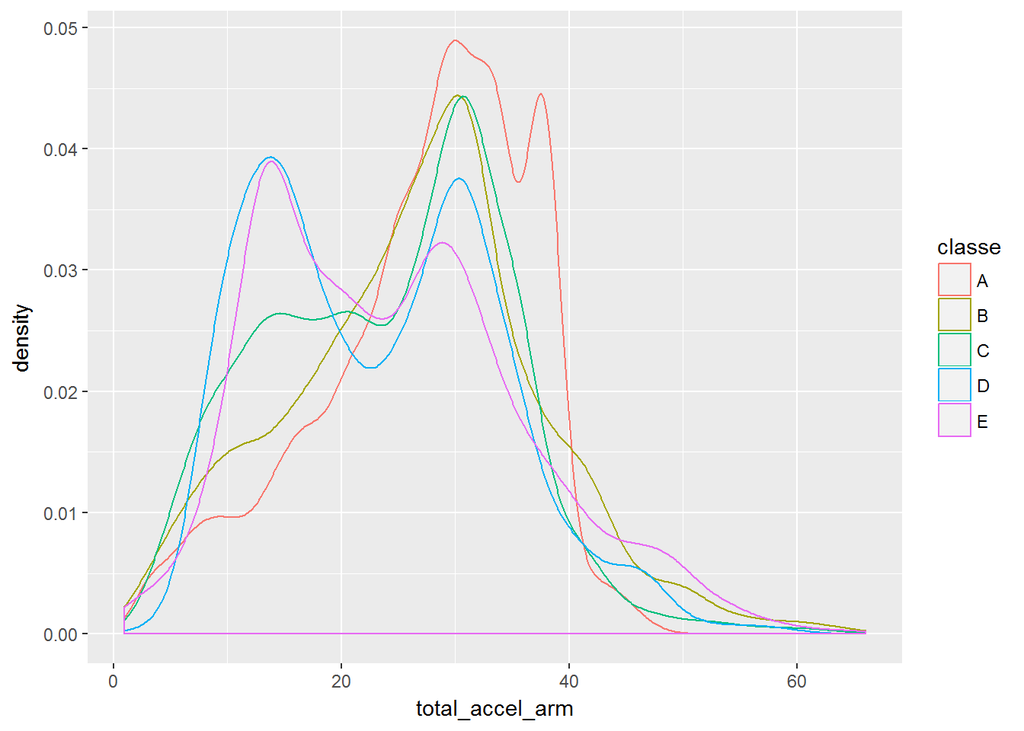

```r
# Density plots
qplot(total_accel_arm,colour=classe,
      data=exerciseData, geom="density")
```

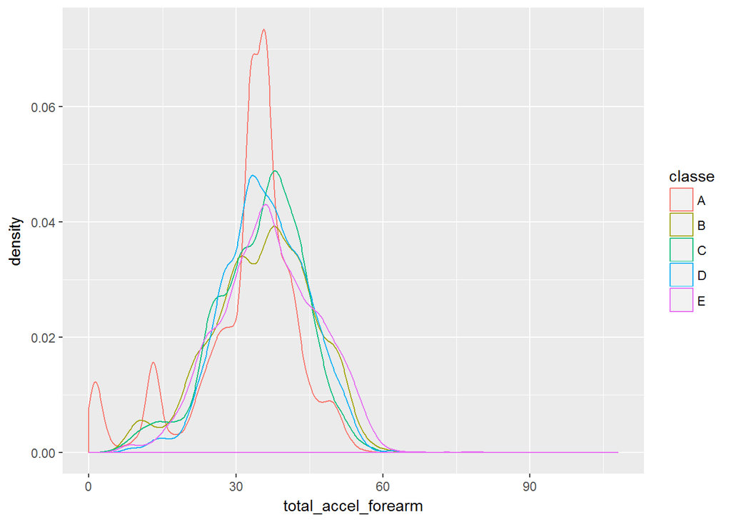

```r
qplot(total_accel_forearm,colour=classe,
      data=exerciseData,geom="density")
```

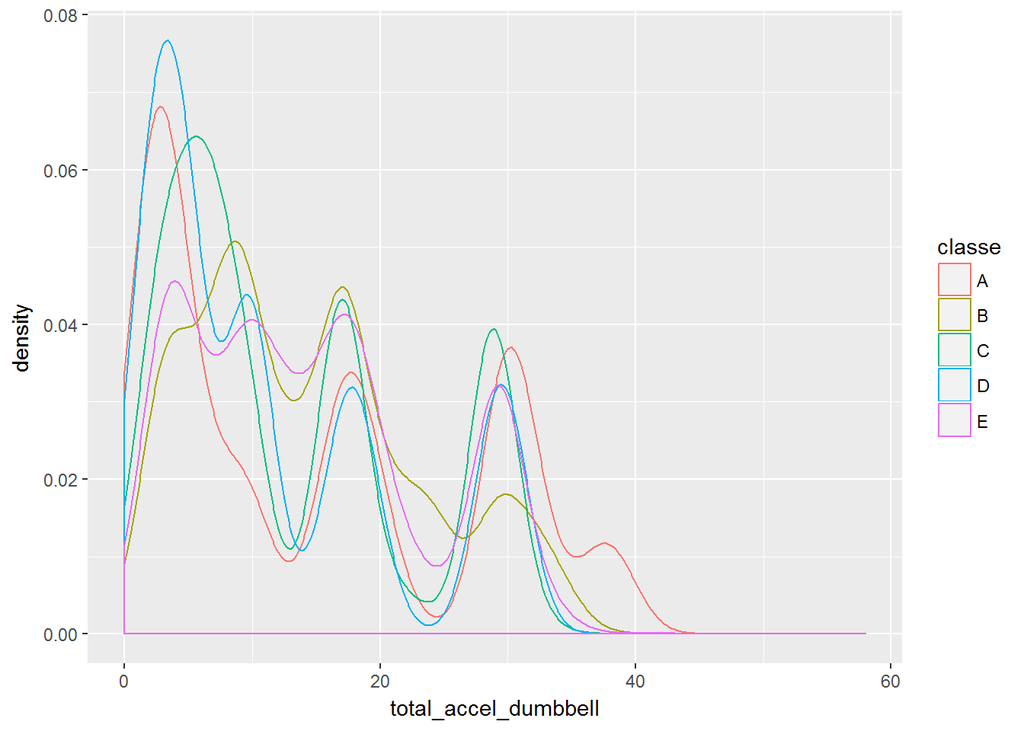

```r
qplot(total_accel_dumbbell,colour=classe,
      data=exerciseData, geom="density")
```

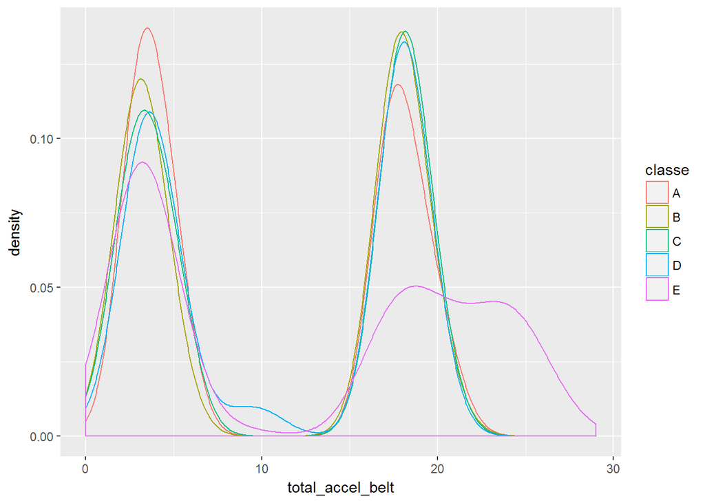

```r
qplot(total_accel_belt,colour=classe,
      data=exerciseData, geom="density")
```

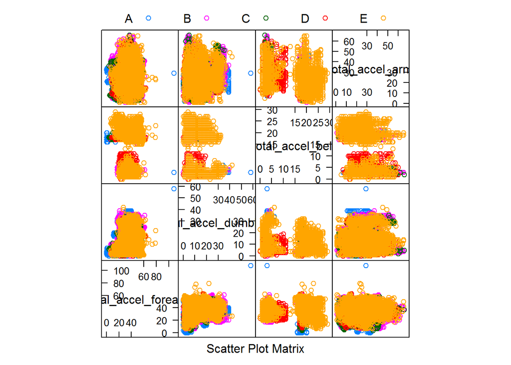

```r
featurePlot(x=exerciseData[,c("total_accel_forearm","total_accel_dumbbell","total_accel_belt","total_accel_arm")],
            y=exerciseData$classe,
            plot="pairs",
            auto.key=list(columns = 5))
```